# IE 582 Statistical Learning for Data Mining - HW2

### Second part of the preprocessing (converting datetime columns, calculating match minutes, and odds)

```python
# Convert datetime columns (if not already handled)
datetime_columns = ['match_start_datetime']  # 'current_time' and 'half_start_datetime' handled earlier
for col in datetime_columns:
    if col in data.columns:
        data[col] = pd.to_datetime(data[col], errors='coerce')

# Calculate total match minutes
def calculate_match_minute(row):
    if row['halftime'] == '1st-half':
        return row['minute']  # 1st half: minutes as-is
    elif row['halftime'] == '2nd-half':
        return row['minute'] + 45  # 2nd half: add 45 to the minute
    else:
        return np.nan  # Unexpected or missing halftime values

if 'halftime' in data.columns and 'minute' in data.columns:
    data['total_minute'] = data.apply(calculate_match_minute, axis=1)

# Handle missing values in odds columns
odds_columns = ['1', 'X', '2']
for col in odds_columns:
    if col in data.columns:
        data[col] = data.groupby('fixture_id')[col].transform(lambda x: x.fillna(x.mean()))

# Filter out rows where 'suspended' or 'stopped' is True
if 'suspended' in data.columns and 'stopped' in data.columns:
    data = data[~data['suspended'].astype(bool) & ~data['stopped'].astype(bool)]

# Replace remaining zeros in odds columns to avoid division by zero errors
for col in odds_columns:
    if col in data.columns:
        data[col] = data[col].replace(0, np.nan)

# Compute initial probabilities for home win, draw, and away win based on odds
if set(odds_columns).issubset(data.columns):
    data['P_home_win'] = 1 / data['1']
    data['P_draw'] = 1 / data['X']
    data['P_away_win'] = 1 / data['2']

    # Normalize probabilities so they sum to 1
    prob_sum = data['P_home_win'] + data['P_draw'] + data['P_away_win']
    data['P_home_win_norm'] = data['P_home_win'] / prob_sum
    data['P_draw_norm'] = data['P_draw'] / prob_sum
    data['P_away_win_norm'] = data['P_away_win'] / prob_sum

# Remove duplicates to ensure the dataset has unique rows
data = data.drop_duplicates()

# Final overview of the cleaned dataset
print(data.head())
```

```
   fixture_id  halftime        current_time half_start_datetime  \
0  19172016.0  1st-half 2024-08-09 18:11:36 2024-08-09 18:01:37
1  19172016.0  1st-half 2024-08-09 18:27:30 2024-08-09 18:01:37
2  19172016.0  1st-half 2024-08-09 18:28:25 2024-08-09 18:01:37
3  19172016.0  1st-half 2024-08-09 18:29:32 2024-08-09 18:01:37
8  19172016.0  1st-half 2024-08-09 18:34:18 2024-08-09 18:01:37

  match_start_datetime  minute  second latest_bookmaker_update  suspended  \
0  2024-08-09 18:01:37       9      59     2024-08-09 18:11:28      False
1  2024-08-09 18:01:37      25      53     2024-08-09 18:27:24      False
2  2024-08-09 18:01:37      26      48     2024-08-09 18:28:20      False
3  2024-08-09 18:01:37      27      55     2024-08-09 18:29:28      False
8  2024-08-09 18:01:37      32      41     2024-08-09 18:34:12      False

   stopped  ...  current_state  final_score  result total_minute  P_home_win  \
0    False  ...              X          2-1       1            9    0.819672
1    False  ...              X          2-1       1           25    0.833333
2    False  ...              X          2-1       1           26    0.833333
3    False  ...              X          2-1       1           27    0.833333
8    False  ...              X          2-1       1           32    0.833333

     P_draw  P_away_win  P_home_win_norm  P_draw_norm  P_away_win_norm
0  0.153846    0.100000         0.763538     0.143310         0.093152
1  0.166667    0.076923         0.773810     0.154762         0.071429
2  0.166667    0.076923         0.773810     0.154762         0.071429
3  0.166667    0.076923         0.773810     0.154762         0.071429
8  0.166667    0.066667         0.781250     0.156250         0.062500

[5 rows x 107 columns]
```

The odds columns (1, X, and 2), representing the probabilities of a home win, draw, and away win, are processed next. Missing values in these columns are imputed with the mean odds for the respective match, preserving match-level trends and avoiding arbitrary replacements. Rows with invalid match data—where suspended or stopped is marked as True—are filtered out to retain only reliable data for analysis. Additionally, zeros in the odds columns, which would lead to computational errors during probability calculations, are replaced with NaN.

Using the cleaned odds data, the script calculates the initial probabilities for home win, draw, and away win by taking the reciprocal of their respective odds. These probabilities are normalized by dividing each by the total probability sum for each row, ensuring they sum to 1 while accounting for potential bookmaker margins. Duplicate rows are subsequently removed to eliminate redundancy.

The final dataset is reviewed with a quick preview using print(data.head()). This comprehensive preprocessing pipeline ensures the dataset is not only cleaned but also consistent, reliable, and prepared for further analysis or modeling. By methodically handling missing data, filtering unreliable rows, and computing normalized probabilities, the script demonstrates a systematic approach to data preparation.

## Task 1

[output not shown]

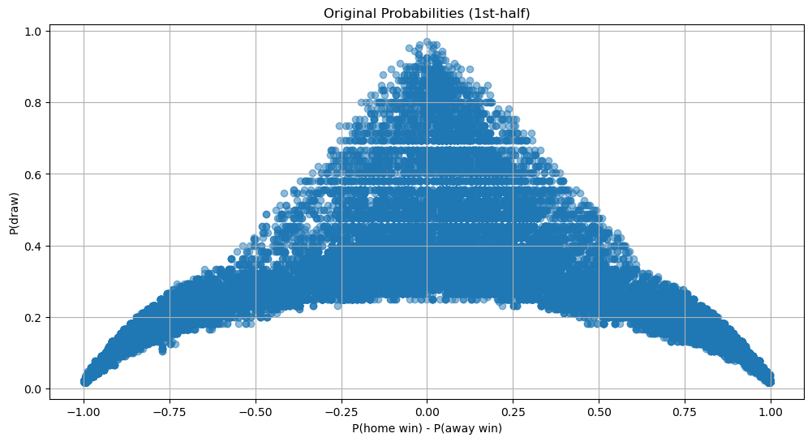

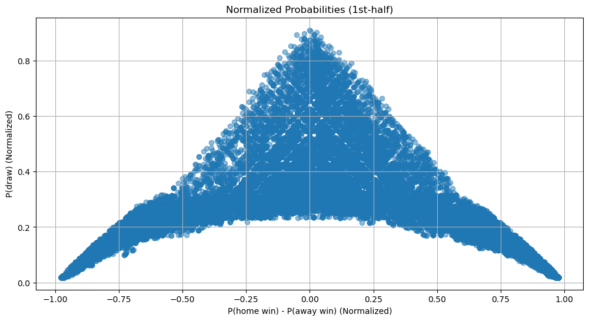

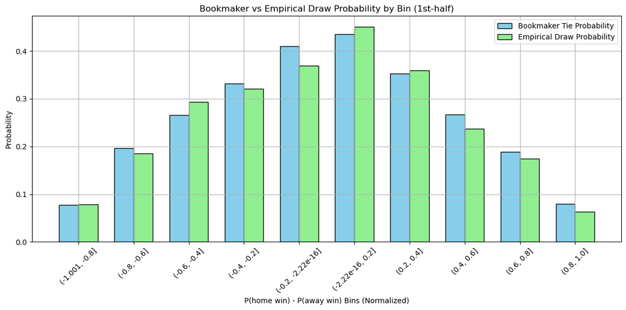

[output not shown]

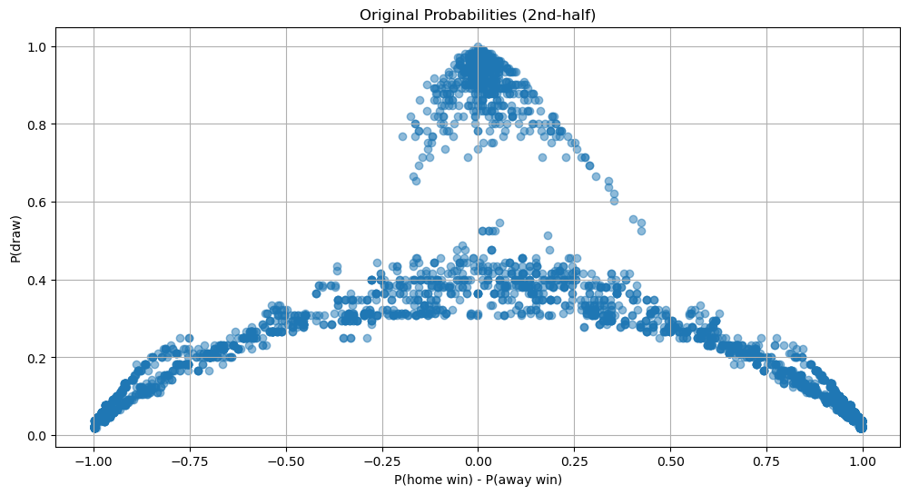

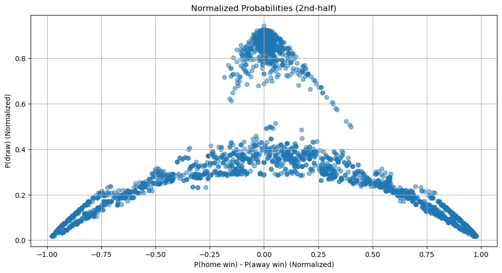

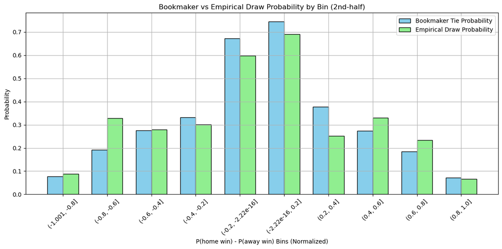

```python
import pandas as pd
import numpy as np
import matplotlib.pyplot as plt

# Assuming 'data' is your preprocessed DataFrame
# Filter for valid rows (no suspended or stopped odds)
data = data[(data['suspended'] == False) & (data['stopped'] == False)]

# Function to analyze each half
def analyze_half(data, half_name):
    # Filter for the specific half
    half_data = data[data['halftime'] == half_name]

    # Calculate implied probabilities
    half_data['P_home_win'] = 1 / half_data['1']
    half_data['P_draw'] = 1 / half_data['X']
    half_data['P_away_win'] = 1 / half_data['2']

    # Normalize probabilities
    prob_sum = half_data[['P_home_win', 'P_draw', 'P_away_win']].sum(axis=1)
    half_data['P_home_win_norm'] = half_data['P_home_win'] / prob_sum
    half_data['P_draw_norm'] = half_data['P_draw'] / prob_sum
    half_data['P_away_win_norm'] = half_data['P_away_win'] / prob_sum

    # Plot 1: Original probabilities
    plt.figure(figsize=(12, 6))
    plt.scatter(
        half_data['P_home_win'] - half_data['P_away_win'],
        half_data['P_draw'],
        alpha=0.5
    )
    plt.title(f"Original Probabilities ({half_name})")
    plt.xlabel("P(home win) - P(away win)")
    plt.ylabel("P(draw)")
    plt.grid()
    plt.show()

    # Plot 2: Normalized probabilities
    plt.figure(figsize=(12, 6))
    plt.scatter(
        half_data['P_home_win_norm'] - half_data['P_away_win_norm'],
        half_data['P_draw_norm'],
        alpha=0.5
    )
    plt.title(f"Normalized Probabilities ({half_name})")
    plt.xlabel("P(home win) - P(away win) (Normalized)")
    plt.ylabel("P(draw) (Normalized)")
    plt.grid()
    plt.show()

    # Discretize "P(home win) - P(away win)" values into bins
    bins = np.arange(-1, 1.1, 0.2)  # Adjust bin size as needed
    half_data['diff_bins'] = pd.cut(
        half_data['P_home_win_norm'] - half_data['P_away_win_norm'],
        bins=bins,
        include_lowest=True
    )

    # Calculate average bookmaker tie probability (P(draw)) for each bin
    bookmaker_draws = half_data.groupby('diff_bins')['P_draw'].mean().reset_index()
    bookmaker_draws.columns = ['Bin', 'BookmakerTieRate']

    # Calculate empirical draw probability by bin
    empirical_draw_probabilities = (
        half_data.groupby('diff_bins')['result']
        .apply(lambda x: (x == 'X').mean())
        .reset_index()
    )
    empirical_draw_probabilities.columns = ['Bin', 'EmpiricalDrawRate']

    # Merge the bookmaker and empirical draw probabilities
    combined_draws = pd.merge(bookmaker_draws, empirical_draw_probabilities, on='Bin')

    # Plot 3: Combined plot for Bookmaker Tie Probability and Empirical Draw Probability
    plt.figure(figsize=(12, 6))
    bar_width = 0.35
    index = np.arange(len(combined_draws))

    plt.bar(index, combined_draws['BookmakerTieRate'], bar_width, label='Bookmaker Tie Probability', color='skyblue', edgecolor='black')
    plt.bar(index + bar_width, combined_draws['EmpiricalDrawRate'], bar_width, label='Empirical Draw Probability', color='lightgreen', edgecolor='black')

    plt.title(f"Bookmaker vs Empirical Draw Probability by Bin ({half_name})")
    plt.xlabel("P(home win) - P(away win) Bins (Normalized)")
    plt.ylabel("Probability")
    plt.xticks(index + bar_width / 2, combined_draws['Bin'].astype(str), rotation=45)
    plt.legend()
    plt.grid(True)
    plt.tight_layout()
    plt.show()

# Analyze each half
for half in ['1st-half', '2nd-half']:
    analyze_half(data, half)
```